# Lista 1 - Questão 15

```r
library(dplyr)
library(ggplot2)
library(forcats)
library(magrittr)
library(broom)
source("plot_functions.R")
```

# 15-a) Modelo desconsiderando etiologia

O modelo que explica a variação do consumo de oxigênio (VO2) da carga de compensação respiratório (carga) desconsiderando as etiologias é $Y_{i j} = \alpha + \beta (x_{i j} - \bar{x}) + \epsilon_{i j}, \epsilon \sim N(0, \sigma^2)$, onde

- $Y_{i j}$ e $x_{i j} - \bar{x}$ é o VO2 e a carga (centrada na média) do i-ésimo indivíduo da j-ésima etiologia, respectivamente
- $\alpha$ é o VO2 esperado quando a carga assume seu valor médio

# 15-b) Modelo considerando etiologia com interação

Seja $i = 1, 2, 3, 4$ índices para as etiologias “C”, “CH”, “ID e”IS", respectivamente e $d_i = 1$ quando a etiologia assume o valor associado ao0 índice $i$ e $d_i = 0$ caso contrário.

O modelo que explica a variação do consumo de oxigênio (VO2) da carga de compensação respiratório (carga) considerando as etiologias é

$$Y_{i j} = \alpha + \beta (x_{i j} - \bar{x}) + \gamma_2 d_2 + \gamma_3 d_3 + \gamma_4 d_4 + \epsilon_{i j}, \epsilon \sim N(0, \sigma^2) + \delta_2 d_i(x_{i j} - \bar{x}) + \delta_3 d_i(x_{i j} - \bar{x}) + \delta_4 d_i(x_{i j} - \bar{x})$$

Onde

- $Y_{i j}$ e $x_{i j}$ é o VO2 e a carga do i-ésimo indivíduo da j-ésima etiologia, respectivamente.
- $\alpha$ é o VO2 esperado quando a etiologia é “C” (casela de referência) e a carga assume seu valor médio
- $\beta$ é a variação esperada de VO2 quando a carga varia em uma unidade e a etiologia é “C”
- $\gamma_i$ é o VO2 esperado quando a etiologia assume valor associado ao índice $i$ e a carga assume seu valor médio
- $\beta + \delta_i$ é a variação esperada de VO2 quando a carga varia em uma unidade e a etiologia assume o valor associado ao índice $i$

# 15-c) Hipóteses de interesse

Para o item a), uma hipótese de interesse é $H_0: \beta = 0$ $H_1: \beta \neq 0$. Em termos do problema, isso significa testar se a carga tem efeito no VO2 de um indivíduo.

Para o item b), uma hipótese de interesse é $H_0: \gamma_2 = \gamma_3 = \gamma_4 = 0$ $H_1: \text{para algum algum} \ i \ \text{tal que} \ \gamma_i \neq 0$. Em termos do problema, isso significa testar se os efeitos das etiologias no VO2 são iguais.

# 15-d) Análise descritiva

Na figura abaixo estão os boxplots do consumo de oxigênio (VO2) para cada etiologia. Ela indica que o VO2 da etiologia “C” é em média maior que o VO2 das demais etiologias.

Apesar de o VO2 ter distribuição diferente para as outras etiologias, essa diferença é mais atenuada e não é possível concluir, apenas da através da análise descritiva, que o VO2 médio é diferente para as etiologias “CH”, “ID” e “IS”.

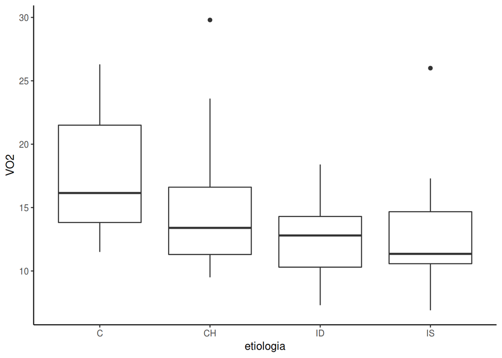

```r
ggplot(df, aes(etiologia, VO2)) + geom_boxplot() + geom_smooth(method = "lm",
    se = FALSE) + theme_classic()
```

# 15-e) Modelo do item a)

```r
modelo_simples <- df %$% lm(VO2 ~ I(carga - mean(carga)))

tidy(modelo_simples, conf.int = TRUE) %>% select(-statistic) %>%
    knitr::kable()
```

[output not shown]

A figura seguinte apresenta o gráfio do VO2 em função da carga, a reta ajustada e o intervalo de confiança para as predições (área em torno da reta).

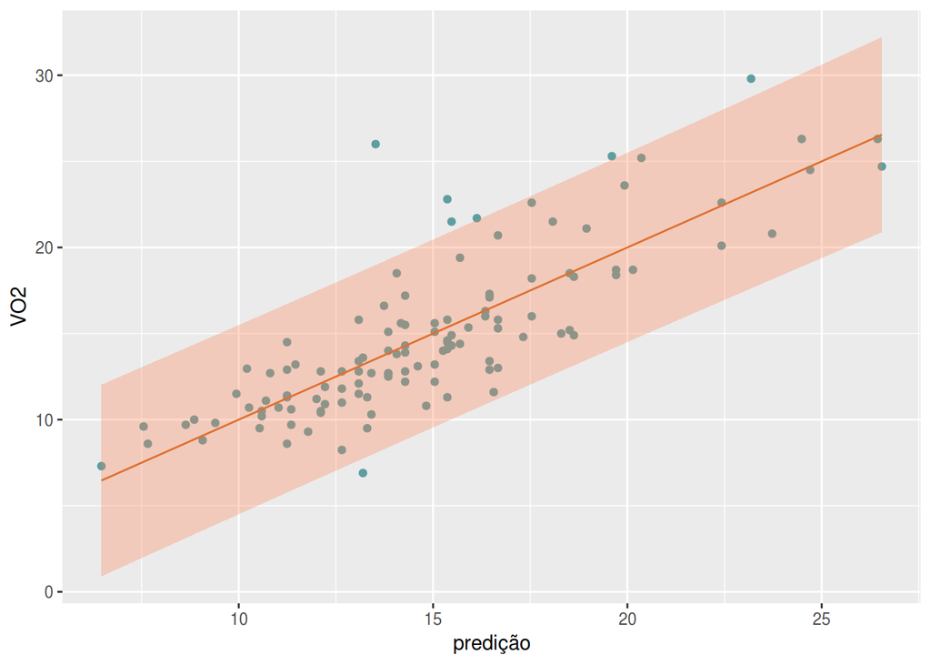

```r
plot_prediction(modelo_simples, df$VO2, "VO2")
```

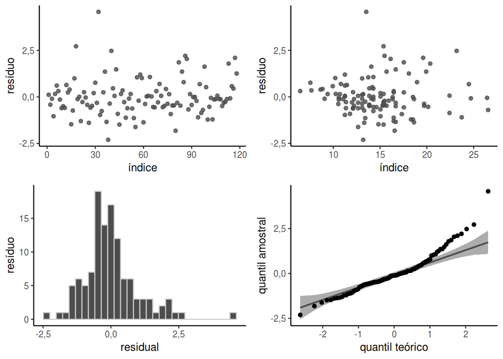

```r
plot_residuals(modelo_simples)
```

# 16 Modelo do item b)

```r
modelo_etiologia <- df %$% lm(VO2 ~ etiologia * I(carga - mean(carga)))

tidy(modelo_etiologia, conf.int = TRUE) %>% select(-statistic) %>%
    knitr::kable()
```

[output not shown]

Isso indica que é razoável desconsiderar um modelo aditivo, i.e., sem interações: $Y_{i j} = \alpha + \gamma_2 d_2 + \gamma_3 d_3 + \gamma_4 d_4 + \beta (x_{i j} - \bar{x})+ \epsilon_{i j}, \epsilon \sim N(0, \sigma^2)$,

Onde

- $Y_{i j}$ e $x_{i j}$ é o VO2 e a carga do i-ésimo indivíduo da j-ésima etiologia, respectivamente.
- $\alpha$ é o VO2 esperado quando a etiologia é “C” (casela de referência) e a carga assume seu valor médio
- $\beta$ é a variação esperada de VO2 quando a carga varia em uma unidade
- $\gamma_i$ é o VO2 esperado quando a etiologia assume valor associado ao índice $i$ e a carga assume seu valor médio

```r
modelo_etiologia <- df %$% lm(VO2 ~ etiologia + I(carga - mean(carga)))

tidy(modelo_etiologia, conf.int = TRUE) %>% select(-statistic) %>%
    knitr::kable()
```

[output not shown]

A figura seguinte apresenta o gráfio do VO2 em função da carga, a reta ajustada e o intervalo de confiança para as predições (área em torno da reta).

A próxima figura apresenta os gráficos de análise de resíduos: o primeiro gráfico não sugere qualquer anormalidade, como dependência; o segundo indica heterocedasticidade; o terceiro indica que pode ser razoável a normalidade, no entanto, o quarto gráfico demonstra não ser possível tal suposição, visto que o QQ-plot tem concavidade para cima e granda parte da cauda positiva fora da banda de confiança.

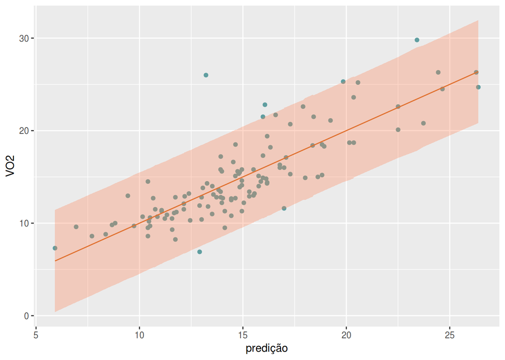

```r
plot_prediction(modelo_etiologia, df$VO2, "VO2")
```

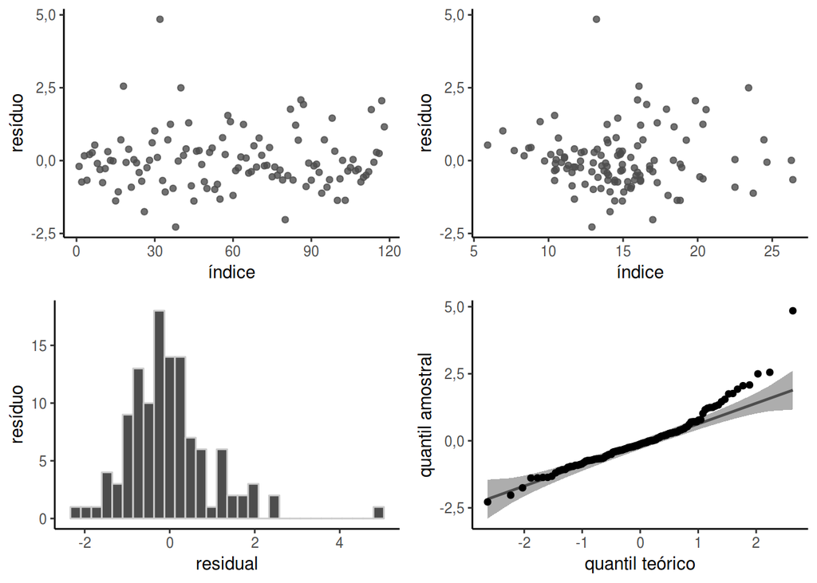

```r
plot_residuals(modelo_etiologia)
```

## Modelo reduzido ao máximo

```r
df <- mutate(df, etiologia = forcats::fct_collapse(etiologia,
    Other = c("C", "CH"), IS = "IS", ID = "ID"))

modelo_reduzido <- df %$% lm(VO2 ~ etiologia + I(carga - mean(carga)))

tidy(modelo_reduzido, conf.int = TRUE) %>% select(-statistic) %>%
    knitr::kable()
```

[output not shown]

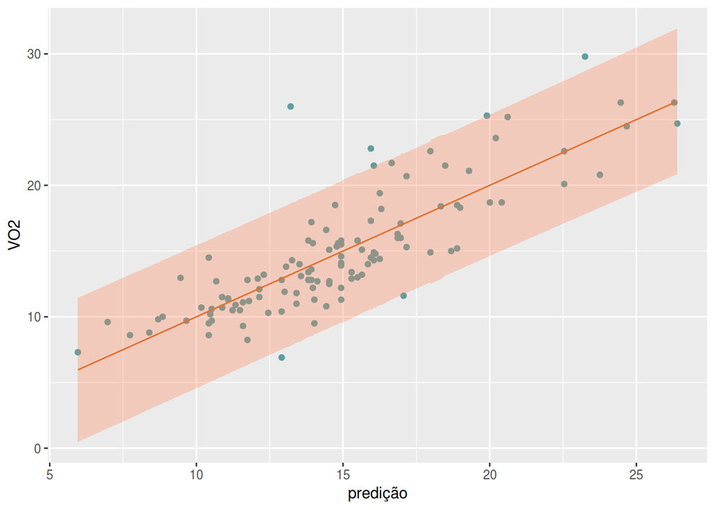

```r
plot_prediction(modelo_reduzido, df$VO2, "VO2")
```

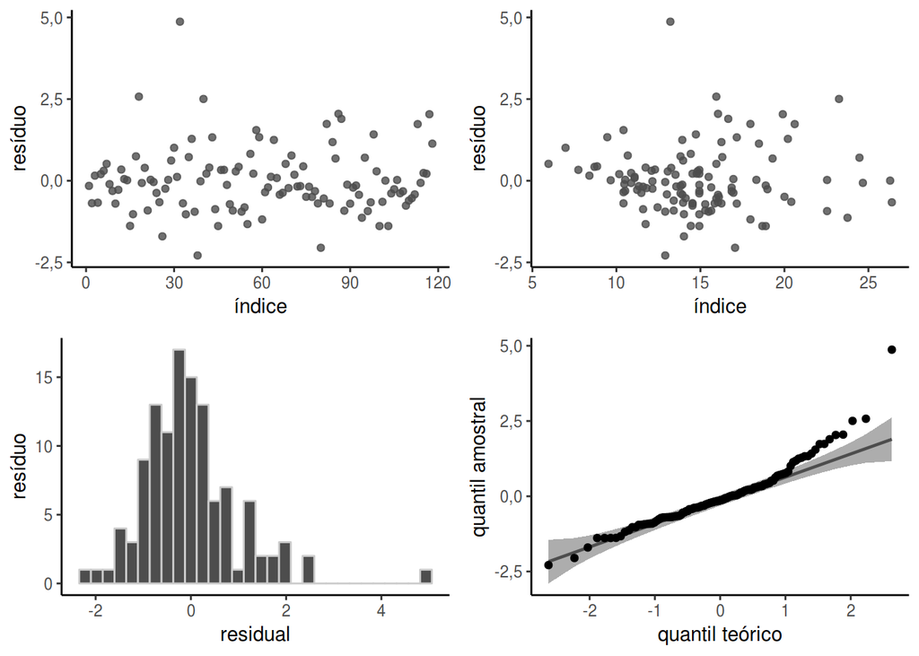

```r
plot_residuals(modelo_reduzido)
```